# Methods and Protocols - TranLab (Purdue University) 2026

Sagar Utturkar

2026-02-14

# Pre-requisites:

## Hardware:

```
This pipeline is primarily designed for execution on Linux based operating systems.
Most of the protocol steps can be executed on a modern personal computer, such as one
equipped with an Intel Core i7 processor and 16 GB of memory. However, for the
alignment step, it is highly recommended to utilize a High-Performance Computing (HPC)
cluster. Using the HPC cluster likely reduce the processing time from weeks to days or
days to hours based on specific tasks.

We have enlisted minimum and recommended hardware requirements for RNA-seq analysis below:

Expected data:
Bulk RNA-seq (typical 30–50 Million reads/sample, ~10 samples)

Miminum hardware:
  1. CPU: 8 cores
  2. RAM: 32–64 GB
  3. Disk: ≥ 200 GB (HDD for storage, SSD for fast I/O is recommended)
  4. OS: Linux (Ubuntu, CentOS, etc.)

Recommended hardware:
  1. CPU: 16-32 cores
  2. RAM: 128 GB
  3. Disk: ≥ 500 GB (HDD for storage, SSD for fast I/O is recommended)
  4. OS: Linux (Ubuntu, CentOS, etc.)
```

## Linux based software/tools:

```bash
# We expect following tools available/installed with Linux-based system
# We refer to each tool as module and loaded below with command 'moule load <Tool_Name>'

module load fastp
module load fastqc
module load star
module load samtools
module load subread
module load rseqc
module load csvtk
module load tpmcalculator
```

## R-packages:

```r
library(DESeq2)
library(ggplot2)
library(gplots)
library(tidyverse)
library(RColorBrewer)
library(edgeR)
library(ggrepel)
library(ComplexHeatmap)
library(dplyr)
library(EnhancedVolcano)
library(circlize)
library(msigdbr)
library(clusterProfiler)
library(org.Hs.eg.db)
library(ggvenn)
library(openxlsx)
library(corrplot)
```

# Step 1: Preparation: day 1

**Timing: 2 hours**

## Create working directory:

```bash
# All analysis should be carried out in a specific directory.
# Here we define a base directory as "RNAseq_Analysis" and
# all paths are in reference to this base directory.

cd ~
mkdir RNAseq_Analysis
```

## Download reference data:

Raw FASTQ files were obtained from GSE255741 (Supinoxin) and GSE142024 (DDX5). Reference human genome sequence (hg38) in FASTA format and annotation in GTF format was downloaded from Ensembl genome browser (https://www.ensembl.org/). BED format gene annotations for Human (hg38_GENCODE_V47.bed.gz) were downloaded from (https://sourceforge.net/projects/rseqc/files/BED/Human_Homo_sapiens/).

```bash
cd ~/RNAseq_Analysis/

mkdir input

# Copy or download the paired-end FASTQ data.
# For this instruction, we assume data is labelled as:
# control1_1.fastq.gz  and  control1_2.fastq.gz

##########

mkdir reference
cd reference

wget https://ftp.ensembl.org/pub/release-114/fasta/homo_sapiens\
/dna/Homo_sapiens.GRCh38.dna.toplevel.fa.gz

gunzip Homo_sapiens.GRCh38.dna.toplevel.fa.gz
mv Homo_sapiens.GRCh38.dna.toplevel.fa genome_ref.fasta

##########

cd ~/RNAseq_Analysis/

mkdir annotations
cd annotations

wget https://ftp.ensembl.org/pub/release-114/gtf/\
homo_sapiens/Homo_sapiens.GRCh38.114.chr.gtf.gz

gunzip Homo_sapiens.GRCh38.114.chr.gtf.gz
mv Homo_sapiens.GRCh38.114.chr.gtf genome_ref.gtf

##########

wget https://sourceforge.net/projects/rseqc/files/BED/\
Human_Homo_sapiens/hg38_GENCODE_V47.bed.gz

gunzip hg38_GENCODE_V47.bed.gz
sed -i 's/^chr//g'  hg38_GENCODE_V47.bed
```

> **Note:** We have included a specific version (release-114) of human genome in our download link above to ensure reproducibility. The genome assembly and annotations are frequently updated, and it is recommended to use the latest version of assembly and annotations. The underlaying biology and pathways should not change but results for individual genes, counts and significance may have changes pertaining to annotation updates.

> **Note:** The RNAseq data used in current analysis were published earlier. While earlier publications included key RNAseq results (differential-expression, top enriched pathways) and brief methods, end-to-end workflow to analyze RNAseq data was not included. The current publication includes step-by-step workflow with detailed instructions and working code to reproduce the results. This end-to-end RNAseq workflow will serve as a primer to perform standard RNAseq analysis on other relevant datasets.

# Step 2: Quality control of FASTQ data: day 1

**Timing: up to 4 hours per sample**

## a. Quality assessment

Quality assessment for each data was performed using fastqc tool.

```bash
cd ~/RNAseq_Analysis/

mkdir quality_control
cd quality_control

mkdir fastqc_before
cd fastqc_before

mkdir control1

fastqc ~/RNAseq_Analysis/input/control1_1.fastq.gz -t 30  -o control1
fastqc ~/RNAseq_Analysis/input/control1_2.fastq.gz -t 30  -o control1

# Repeat above steps for every FASTQ file for each sample
```

## b. Quality-based trimming

Quality-based trimming (removal of adapters, low quality bases and short sequences) fastp. After trimming, re-assessment of trimmed data was performed using fastqc to ensure optimal data quality.

```bash
cd ~/RNAseq_Analysis/

mkdir fastp
cd fastp

# Processing for sample control1

fastp -w 30 \
-i ~/RNAseq_Analysis/input/control1_1.fastq.gz \
-I ~/RNAseq_Analysis/input/control1_2.fastq.gz \
-o control1_1.trimmed.fastq.gz \
-O control1_2.trimmed.fastq.gz \
--length_required  50 \
-q 30 \
--detect_adapter_for_pe  \
-h control1.html  \
-j control1.fastp.json


cd ~/RNAseq_Analysis/quality_control/

mkdir fastqc_after
cd fastqc_after

mkdir control1.trimmed

fastqc ~/RNAseq_Analysis/quality_control/fastp/control1_1.trimmed.fastq.gz \
-t 30 \
-o control1.trimmed

fastqc ~/RNAseq_Analysis/quality_control/fastp/control1_2.trimmed.fastq.gz \
-t 30 \
-o control1.trimmed

# Repeat above steps for each sample
```

# Step 3: Indexing reference genome: day 1

**Timing: 4 hours**

## a. Indexing:

Indexing of reference genome (structured representation of a genome to enable faster and more efficient searching and alignment of DNA sequences) was performed through STAR aligner.

```bash
cd ~/RNAseq_Analysis/

cd reference

STAR --runThreadN 30 \
--runMode genomeGenerate \
--genomeDir . \
--genomeFastaFiles genome_ref.fasta
```

# Step 4: Alignment with reference genome: day 2

**Timing: up to 6 hours per sample**

## a. Mapping:

1. Quality trimmed reads were mapped to reference genome using the STAR aligner. Alignment summary file was inspected to ensure a suitable percentage of reads are mapped to reference genome. The aligned data (BAM format) was generated for each sample.

```bash
cd ~/RNAseq_Analysis/

mkdir mapping
cd mapping


STAR --runThreadN 30 \
--runMode alignReads \
 --outSAMunmapped Within \
--outSAMattrIHstart 0 \
--outFilterIntronMotifs RemoveNoncanonical  \
--genomeDir ~/RNAseq_Analysis/reference/ \
--readFilesIn ~/RNAseq_Analysis/quality_control/fastp/control1_1.trimmed.fastq.gz
~/RNAseq_Analysis/quality_control/fastp/control1_2.trimmed.fastq.gz  \
--readFilesCommand zcat \
--twopassMode Basic \
--outSAMtype BAM SortedByCoordinate \
--outFileNamePrefix control1.

# --outFilterIntronMotifs RemoveNoncanonical prioritizes robust gene-level quantification

# --twopassMode Basic increases splice junction accuracy and sensitivity

samtools sort -@ 30 -n  control1.Aligned.sortedByCoord.out.bam  -o control1_sortedbyread.bam
samtools index -@ 30   control1.Aligned.sortedByCoord.out.bam
samtools flagstat -@ 30 control1.Aligned.sortedByCoord.out.bam > control1_flagstat.txt

# Repeat above steps for each sample
```

> **Note:**

> `--outFilterIntronMotifs RemoveNoncanonical` option in STAR aligner is used to remove non-canonical splice junctions from the output. Non-canonical splice junctions were filtered out to reduce alignment artifacts and improve the robustness of gene-level quantification. Rare canonical introns (GC–AG, AT–AC) were retained. While noncanonical splicing events may be biologically relevant in cancer, they are often associated with splicing errors and can introduce noise in the data. Noncanonical splicing events are typically rare and require junction-level validation. This was beyond the scope of this study and filtering was appropriate for our (gene-level) analysis goals.

> `--twopassMode Basic` option in STAR aligner is used to perform a two-pass alignment. In the first pass, STAR identifies splice junctions from the initial alignment. In the second pass, STAR re-aligns the reads to augmented junction set and in turn improves sensitivity for novel splice junctions and enhance alignment accuracy.

Acceptance thresholds for key quality metrices and mapping parameters along with recommendations for corrective actions when these criteria are not met are provided in the table below:

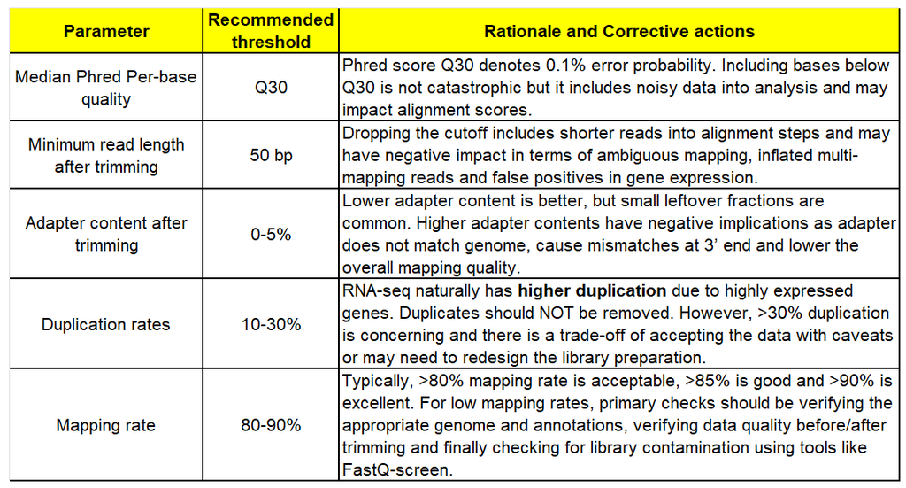

# Step 5: Infer data strandedness: day 3

**Timing: up to 30 minutes per sample**

## running infer_experiment.py script:

Determining if data is stranded or un-stranded (dependent of library preparation and sequencing protocols) is crucial for proper analysis and interpretation of RNAseq data. Stranded protocol preserves the directionality of the transcripts, while non-stranded protocol does not.

```bash
cd ~/RNAseq_Analysis/
cd mapping

samtools view -b -q 255 control1.Aligned.sortedByCoord.out.bam > control1.Aligned.unique.bam

infer_experiment.py \
-i control1.Aligned.unique.bam \
-s 1000000 \
-r  ~/RNAseq_Analysis/annotations/hg38_GENCODE_V47.bed > control1.infer_exp.txt

# Repeat above steps for each sample
```

> **Note:** infer_experiment.py performs random sampling of mapped reads and counts the sense cs. antisense strand reads that overlap with annotated genes. The output provides the fraction of reads assigned to each strand, which helps to determine the strandedness of the data. We used uniquely mapped reads (mapping quality score of 255) for this analysis and remove bias towards repetitive regions and multi-mapped reads. The specific parameter `-s 1000000` was used to sample 1 million reads for the inference. This is a common practice to sampling noise in low-depth sequencing data and avoids unreliable strandedness estimates.

Data strandedness for each sample was determined using the ‘infer_experiment.py’ script from the RSeQC package. The output denotes the fraction of reads assigned to each biological sequence orientation (5’-3’ – forward or 3’-5’ reverse). Generally, for un-stranded libraries, fractions of reads assigned to each orientation are roughly equal (50:50) while for stranded libraries a definitive bias is observed towards one orientation (80:20, 20:80 or similar).

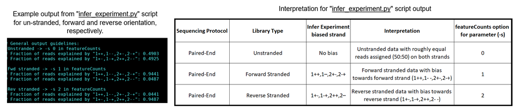

# Step 6: Quantification to generate counts matrix: day 3

**Timing: up to 30 minutes per sample**

## Counts matrix in RNAseq:

```bash
############### QUANTIFICATION_PARAMETER S#########
# -T -> number of processors
# -a -> provide annotation file here
# -o -> provide out prefix
# -t -> provide feature type to quantify for
# -g -> attribute to assign the quantification for
# -s -> specify strandedness here, 0 = unstranded, 1 = stranded and 2 = reverse
# -p -> specify is data is paired end
# -B -> quantify if both ends of the pairs are mapped
###############################################

cd ~/RNAseq_Analysis/

mkdir counts
cd counts

featureCounts -T 30 \
-a ~/RNAseq_Analysis/annotations/genome_ref.gtf \
-o control1.ct \
-s 0 \
-p -B  \
-t gene -g gene_id \
~/RNAseq_Analysis/mapping/control1.Aligned.sortedByCoord.out.bam

# output file "control1.ct" has 7 columns and
# we are interested in column 1 (containing geneID) and column 7 (containing assigned counts)
# We use `cut` command in Linux to extract only  column 1 and column 7
# and save it to another file

grep -v "#" control1.ct | cut -f1,7- > control1.ct.counts

# Repeat above steps for each sample
```

## combine counts:

3. Lastly, a custom script was employed to generate a combined counts matrix where each row represents a gene, and each column represents a sample. The values in the matrix denote the number of reads mapped to each gene in each sample.

```bash
cd ~/RNAseq_Analysis/
cd counts

csvtk join -t $(ls *.counts) | \
sed 's/.Aligned.sortedByCoord.out.bam//g' | \
sed 's/Geneid/Gene_ID/g' > combined_counts.tsv

# Above commands should generate the counts matrix for all the samples
```

## Transcripts Per Million (TPM) counts:

4. Transcripts Per Million (TPM) are normalized counts in RNA-seq data. TPM represents the relative abundance of transcripts, essentially indicating the number of reads detected for a gene if sequenced to one million reads. TPM normalizes for both sequencing depth and transcript length, making it useful for comparing gene expression across different samples.

```bash
cd ~/RNAseq_Analysis/
mkdir TPM
cd TPM

TPMCalculator -p -e -a -b \
~/RNAseq_Analysis/mapping/control1.Aligned.sortedByCoord.out.bam \
-g ~/RNAseq_Analysis/annotations/genome_ref.gtf

# output file "control1.Aligned.sortedByCoord.out_genes.out"
# will be created containing TPM counts

# extract columns of interest (geneID and TPMcounts)

cut -f 1,7 control1.Aligned.sortedByCoord.out_genes.out > control1.TPM.counts

# Repeat above steps for each sample
# combine *.counts files with csvtk

csvtk join -t $(ls *.counts)  > TPM_counts.tsv
```

## TPM counts matrix generation:

5. TPMCalculator program add suffix as “#1”, “#2”, …, “#N” when the same gene ID is denoted at different locations in annotation (GTF) file. For the sake of simplicity, we keep the gene location with maximum assigned counts so that we retain maximum assigned counts for a specific gene to retain the dominant (highly expressed) transcript. This approach prioritizes the dominant expressed locus for the specific gene while reducing the noise from low-expression transcript or ambiguity of annotated gene models. This approach avoids artificial inflation of counts that may occur if counts are summed across multiple loci. This strategy is opted in the context of the goal gene-level differential expression analysis. For other goals such as isoform specific analyses, current strategy may not be appropriate, and it is recommended to keep and review the counts for duplicated genes.

```r
TPM = read.table(file = "TPM_counts.tsv", header = T, sep = "\t", quote = "")

TPM_nohash = TPM %>%
    dplyr::filter(!str_detect(Gene_ID, "#"))

TPM_withhash = TPM %>%
    dplyr::filter(str_detect(Gene_ID, "#"))

TPM_withhash$Gene_ID = str_replace(TPM_withhash$Gene_ID, "#.*", "")


TPM_withhash_unique = as.data.frame(TPM_withhash %>%
    rowwise() %>%
    mutate(Total_counts = sum(c_across(2:length(TPM_withhash)))) %>%
    dplyr::arrange(Gene_ID, desc(Total_counts)) %>%
    dplyr::distinct(Gene_ID, .keep_all = T) %>%
    dplyr::select(-c("Total_counts")))

TPM_final = rbind(TPM_nohash, TPM_withhash_unique)

saveRDS(TPM_final, "TPM_final.rds")
```

## Determine correlation between replicates:

The ENCODE recommendations for replicates concordance is - spearman correlation of > 0.9 between isogenic replicates and >0.8 between anisogenic replicates (i.e. replicates from different donors) (Figure 3). We determined the Spearman’s correlation among replicates and see high concordance (> 0.9) among replicates.

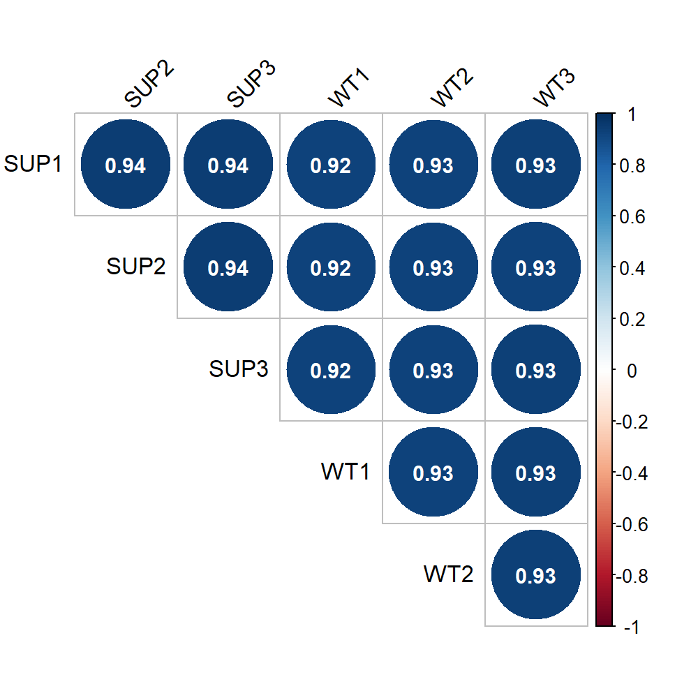

```r
countfile = "counts_Supinoxin.TXT" # provide the path for counts file

raw.data = read.table(countfile, row.names="Gene_ID", header = T,
                      sep = "\t", as.is = T, check.names = F, quote = "")

cor.result <- cor(as.matrix(raw.data), method = "spearman")

corrplot(cor.result,
         method = "circle",
         type = "upper",
         addCoef.col = "white", # Add correlation coefficients as numbers
         number.cex = 0.9, # Adjust size of numbers
         tl.col = "black", # Color of text labels
         tl.srt = 45, # Rotate text labels for better readability
         diag = FALSE
         )
```

# Step 7: Differential Expression (DE) analysis: day 4

**Timing: up to 4 hours**

## DE_edger.R script for differential gene expression:

1. DE analysis identifies genes with significant changes in expression levels between two or more conditions. The analysis involves statistical tests to determine if observed differences in gene expression are likely due to biological factors rather than random noise.

```r
# A complete script is available on GitHub as DE_edger.R

library(DESeq2)
library(ggplot2)
library(gplots)
library(tidyverse)
library(RColorBrewer)
library(edgeR)
library(ggrepel)
library(ComplexHeatmap)
library(dplyr)

args <- commandArgs(trailingOnly = TRUE)

countfile = args[1]  #path for the counts file
control = args[2]  #name for control (as in counts file)
treatment = args[3]  #name for treatment (as in counts file)
control_rep = args[4]  #number of replicates for control
treatment_rep = args[5]  #number of replicates for treatment
path = args[6]  #path for annotation file

outprefix <- paste(treatment, control, sep = "_vs_")
dir.create(outprefix)
setwd(outprefix)

header = paste(rep("#", 50), collapse = "")

sink(file = paste0(outprefix, ".sessioninfo.txt"))

cat(paste(header, "#Version Information", header, sep = "\n"))
cat("\n")
version
cat("\n")

cat(paste(header, "#Session Information", header, sep = "\n"))
cat("\n")
sessionInfo()
sink()

# Save log to file

sink(file = paste0(outprefix, ".log.txt"))

Anno <- read.table(path, sep = "\t", stringsAsFactors = F, header = TRUE,
    quote = "")

raw.data = read.table(countfile, row.names = "Gene_ID", header = T,
    sep = "\t", as.is = T, check.names = F, quote = "")

control
treatment

group <- factor(rep(c(control, treatment), times = c(control_rep,
    treatment_rep)), levels = c(control, treatment))

group
control_mat <- select(raw.data, starts_with(control))
treatment_mat <- select(raw.data, starts_with(treatment))
raw.counts <- merge(control_mat, treatment_mat, by = "row.names",
    all.x = TRUE)

raw.counts <- column_to_rownames(raw.counts, var = "Row.names")

#### edgeR Analysis

y <- DGEList(counts = as.matrix(raw.counts), group = group)
x <- calcNormFactors(y)

keep <- filterByExpr(y)
filtered.data <- y[keep, keep.lib.sizes = FALSE]
y <- calcNormFactors(filtered.data)

design <- model.matrix(~0 + group)

colnames(design) <- levels(y$samples$group)
y <- estimateDisp(filtered.data, design)
fit <- glmQLFit(y, design)
qlf <- glmQLFTest(fit, contrast = c(-1, 1))

edgeR_DE = as.data.frame(topTags(qlf, sort.by = "PValue", n = Inf))
edgeR_DE = rownames_to_column(edgeR_DE, "Gene_ID")
edgeR_DE = left_join(edgeR_DE, Anno, by = "Gene_ID")

write.table(edgeR_DE, file = paste0(outprefix, ".DE_edgeR_All.txt"),
    sep = "\t", quote = F, row.names = F)

saveRDS(edgeR_DE, file = paste0(outprefix, "edgeR_DE.rds"))

#### Filtering EdgeR - FDR 5% filtered
edgeR_DE_FDR5P = dplyr::filter(edgeR_DE, FDR < 0.05)
dim(edgeR_DE_FDR5P)

write.table(edgeR_DE_FDR5P, file = paste0(outprefix, ".DE_edgeR_5PCT.txt"),
    sep = "\t", quote = F, row.names = F)

sink()
```

2. DE analysis between (DDX5-knockdown and control) and (Supinoxin treated and control) was performed using edgeR R-package.

```r
# DE analysis require (1) DE_edger.R (2) count.matrix (3)
# Annotation file <TAB delimited>

# The script was run on windows computer using rstudio as
# below: Please update complete paths for each file

# DE analysis for Supinoxin data:
system("RScript   DE_edger.R   counts_Supinoxin.TXT   H69ARWT   H69ARSUP  3   3   Annotation.TXT")

# DE analysis for DDX5KD data:
system("RScript   DE_edger.R   counts_DDX5KD.TXT   WT   DDX5KD  3   3   Annotation.TXT")
```

# Step 8: Determine shared up- and down-regulated genes between DDX5KD and Supinoxin data: day 4

**Timing: up to 1 hour**

## Up- and down-regulated genes:

1. In each data, up- and down-regulated genes were denoted as following:
   1. Up-regulated genes - FDR < 0.05 and log2fold-change > 1.
   2. Down-regulated genes - FDR < 0.05 and log2fold-change < -1.

```r
library(dplyr)
library(openxlsx)
library(ggvenn)

setwd("Z:/PCCR/Tran_Elizabeth/Methods_paper/GitHub/data")

SUP.DE = openxlsx::read.xlsx(xlsxFile = "Supinoxin.DE.xlsx",
    sheet = "EdgeR_All")

DDX5KD.DE = openxlsx::read.xlsx(xlsxFile = "DDX5KD.DE.xlsx",
    sheet = "EdgeR_All")

SUP.up = SUP.DE %>%
    dplyr::filter(padj < 0.05) %>%
    dplyr::filter(log2FoldChange > 1)

SUP.down = SUP.DE %>%
    dplyr::filter(padj < 0.05) %>%
    dplyr::filter(log2FoldChange < -1)


DDX5KD.up = DDX5KD.DE %>%
    dplyr::filter(FDR < 0.05) %>%
    dplyr::filter(logFC > 1)


DDX5KD.down = DDX5KD.DE %>%
    dplyr::filter(FDR < 0.05) %>%
    dplyr::filter(logFC < -1)
```

## Venn diagram **(Figure 1A)** for up- and down-regulated genes:

2. A Venn diagram was created using the up- and down-regulated genes from each data using the ggvenn R-package.

```r
my_list = list(DDX5KD.up = DDX5KD.up$Gene_ID, DDX5KD.down = DDX5KD.down$Gene_ID,
    SUP.down = SUP.down$Gene_ID, SUP.up = SUP.up$Gene_ID)

ggvenn(my_list, show_percentage = F, text_size = 8)
```

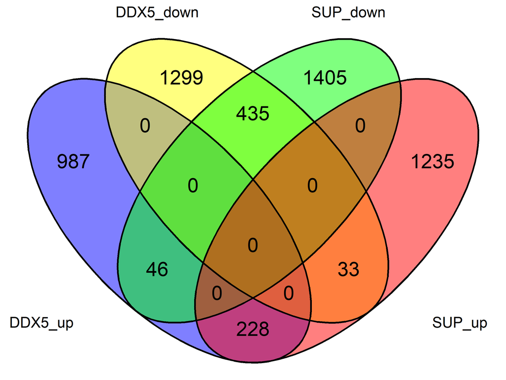

# Step 9: Custom figures: day 4

**Timing: 2 hours**

## Heatmap **(Figure 1B)** with individual replicates:

1. Heatmap denoting the expression patterns for key genes among Supinoxin treated and untreated samples was created using R-package ComplexHeatmap.

```r
SUP_TPM = readRDS(file = "SUP_TPM.rds")

Anno = read.table("Annotation.TXT", sep = "\t", header = T, quote = "")

Anno_select = Anno %>%
    dplyr::select(all_of(c("Gene_ID", "Gene.name")))

TPM_with_symbol = SUP_TPM %>%
    dplyr::left_join(Anno_select) %>%
    dplyr::select(-c("Gene_ID")) %>%
    dplyr::relocate("Gene.name")
```

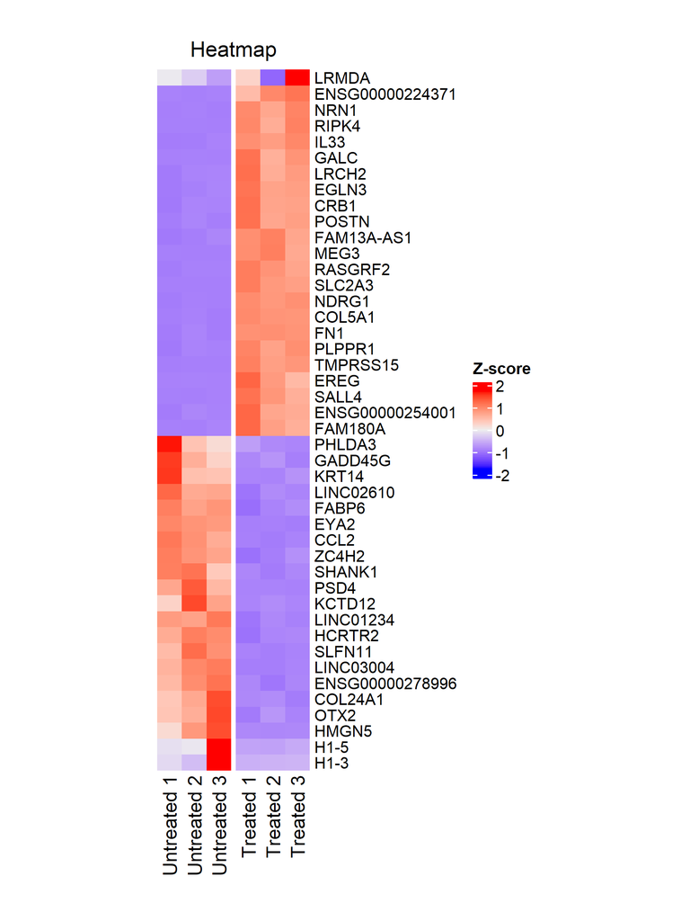

```r
heat_genes = read.table(file = "heatmap.genes.txt", sep = "\t",
    header = T, quote = "")

mat = TPM_with_symbol %>%
    dplyr::filter(Gene.name %in% heat_genes$symbol) %>%
    remove_rownames() %>%
    column_to_rownames("Gene.name") %>%
    dplyr::relocate(starts_with(c("H69ARSUP"))) %>%
    dplyr::relocate(starts_with(c("H69ARWT")))

heat <- t(scale(t(mat)))

colnames(heat) = c("Untreated 1", "Untreated 2", "Untreated 3",
    "Treated 1", "Treated 2", "Treated 3")

HM1 = ComplexHeatmap::Heatmap(heat, name = "Z-score", width = ncol(mat) *
    unit(16, "pt"), height = nrow(mat) * unit(10, "pt"), show_row_names = T,
    show_column_dend = F, show_row_dend = F, row_names_gp = gpar(fontsize = 10),
    column_title = "Heatmap", cluster_columns = F, cluster_rows = T,
    column_split = c("A", "A", "A", "B", "B", "B"))

# Extract row names
x = ComplexHeatmap::row_order(HM1)
y = rownames(heat)[x]
y = as.data.frame(y)
colnames(y) = c("Gene_ID")

write.table(as.data.frame(y), file = "heatmap_row_order.txt",
    sep = "\t", quote = F, row.names = F)
```

## Heatmap **(Figure 1B)** with log2FoldChnage data:

2. Heatmap denoting the up- or down-regulation (log2 fold change) for key genes in Supinoxin treated samples as compared to untreated samples was created using R-package ComplexHeatmap.

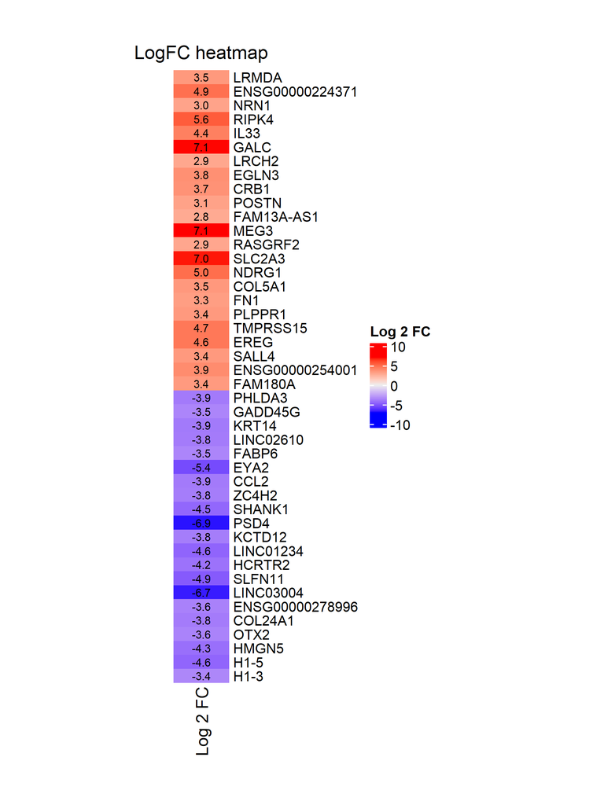

```r
SUP.DE = openxlsx::read.xlsx(xlsxFile =  "Supinoxin.DE.xlsx", sheet = "EdgeR_All")

gene_order = read.table(file = "heatmap_row_order.txt", sep = "\t", header = T, quote = "")

heat_data = gene_order %>%
            dplyr::left_join(SUP.DE, by = c("Gene_ID" = "symbol")) %>%
            dplyr::select(all_of(c("Gene_ID","log2FoldChange"))) %>%
            column_to_rownames("Gene_ID") %>%
            dplyr::rename("LogFC" = "log2FoldChange")

ComplexHeatmap::Heatmap(heat_data,
                        name = "Log 2 FC",
                        width = ncol(heat_data)*unit(40, "pt"),
                        height = nrow(heat_data)*unit(10, "pt"),
                        show_row_names = T,
                        show_column_dend = F,
                        show_row_dend = F,
                        row_names_gp = gpar(fontsize = 10),
                        column_title = "LogFC heatmap",
                        cluster_columns  = F,
                        cluster_rows = F,
                        column_labels = c("Log 2 FC"),
                        cell_fun = function(j, i, x, y, width, height, fill)
                          {
                          grid.text(sprintf("%.1f", heat_data[i, j]),
                                    x, y, gp = gpar(fontsize = 8))
                        }

)
```

## Heatmap **(Figure 1B)** with Average Expression data:

3. Heatmap denoting the average expression across Supinoxin treated and untreated samples was created using R-package ComplexHeatmap.

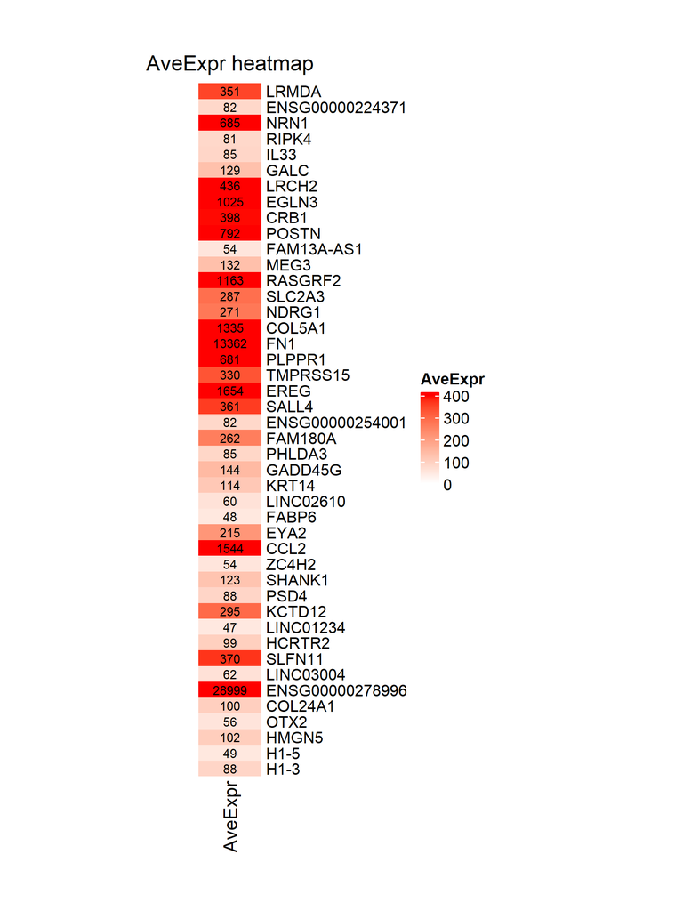

```r
Anno = read.table("Annotation.TXT", sep = "\t", header = T, quote = "")

gene_order = read.table(file = "heatmap_row_order.txt", sep = "\t", header = T, quote = "")

my_counts = read.table(file = "counts_Supinoxin.TXT", sep = "\t", header = T, quote = "")

my_counts = my_counts %>%
            dplyr::left_join(Anno) %>%
            dplyr::mutate(Gene.name = ifelse(is.na(Gene.name), Gene_ID, Gene.name)) %>%
            dplyr::select(all_of(c("Gene.name",
                                   "H69ARWT1", "H69ARWT2", "H69ARWT3",
                                   "H69ARSUP1", "H69ARSUP2", "H69ARSUP3" )))

heat_counts = gene_order %>%
              dplyr::left_join(my_counts, by = c("Gene_ID" = "Gene.name")) %>%
              column_to_rownames("Gene_ID") %>%
              dplyr::mutate(AveExpr = rowSums(.)/6) %>%
              dplyr::select(all_of(c("AveExpr")))

col_fun = colorRamp2(c(0, 400), c( "white", "red"))

ComplexHeatmap::Heatmap(heat_counts,
                        name = "AveExpr",
                        col = col_fun,
                        width = ncol(heat_counts)*unit(40, "pt"),
                        height = nrow(heat_counts)*unit(10, "pt"),
                        show_row_names = T,
                        show_column_dend = F,
                        show_row_dend = F,
                        row_names_gp = gpar(fontsize = 10),
                        column_title = "AveExpr heatmap",
                        cluster_columns  = F,
                        cluster_rows = F,
                        cell_fun = function(j, i, x, y, width, height, fill)
                          {
                          grid.text(sprintf("%.0f", heat_counts[i, j]),
                                    x, y, gp = gpar(fontsize = 8))
                        }

)
```

## Volcanoplot **(Figure 1C)**:

4. A volcano plot displaying key differentially expressed genes (-Log10PValue on Y-axis) along with up- or down-regulation (log2 fold change on X-axis) in Supinoxin data was created using R-package EnhancedVolcano.

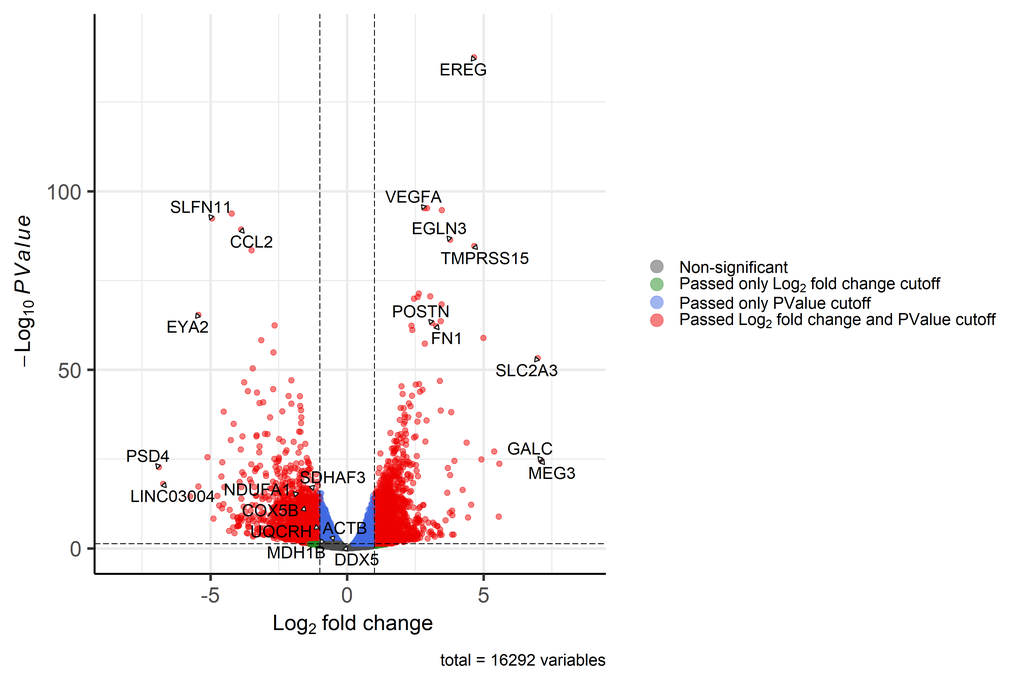

```r
SUP.DE = openxlsx::read.xlsx(xlsxFile = "Supinoxin.DE.xlsx",
    sheet = "EdgeR_All")

label_data = c("EREG", "SLFN11", "CCL2", "EYA2", "PSD4", "LINC03004",
    "SDHAF3", "NDUFA1", "COX5B", "UQCRH", "MDH1B", "ACTB", "DDX5",
    "GALC", "MEG3", "SLC2A3", "FN1", "POSTN", "TMPRSS15", "EGLN3",
    "VEGFA", "EREG")

EnhancedVolcano(SUP.DE, lab = SUP.DE$symbol, subtitle = NULL,
    selectLab = label_data, x = "log2FoldChange", y = "pvalue",
    ylab = bquote(~-Log[10] ~ italic(PValue)), title = NULL,
    legendLabels = c("Non-significant", as.expression(bquote("Passed only" ~
        Log[2] ~ "fold change cutoff")), "Passed only PValue cutoff",
        as.expression(bquote("Passed" ~ Log[2] ~ "fold change and PValue cutoff"))),
    FCcutoff = 1, pCutoff = 0.05, legendPosition = "right", maxoverlapsConnectors = Inf,
    drawConnectors = T)
```

# Step 10: Pathway analysis: day 4

**Timing: up to 2 hours**

## Database for pathway analysis:

```r
# Pathaway analysis (GSEA) for Supinoxin data:

library(clusterProfiler)
library(msigdbr)
library(org.Hs.eg.db)
library(dplyr)

db = "org.Hs.eg.db"

# read “Hallmark” gene set from Molecular Signature
# Database (MSigDB)

hallmark_t2g <- msigdbr(species = "Homo sapiens", category = "H") %>%
    dplyr::select(gs_name, entrez_gene)

SUP_ranked = read.table(file = "SUP_GSEA.rnk", quote = "", sep = "\t",
    header = T)

SUP_ranked = dplyr::arrange(SUP_ranked, desc(Rank))

#######################################

x <- bitr(SUP_ranked$Gene_ID, fromType = "ENSEMBL", toType = "ENTREZID",
    OrgDb = db)

x = x %>%
    dplyr::left_join(SUP_ranked, by = c(ENSEMBL = "Gene_ID")) %>%
    dplyr::select(all_of(c("ENTREZID", "Rank"))) %>%
    dplyr::arrange(desc(Rank))

SUP_genelist = x$Rank
names(SUP_genelist) = x$ENTREZID

#######################################

SUP_GSEA <- GSEA(SUP_genelist, TERM2GENE = hallmark_t2g, , pvalueCutoff = 1)

saveRDS(SUP_GSEA, file = "SUP_GSEA_Hallmark.rds")

write.table(SUP_GSEA, file = "SUP_GSEA_Hallmark_Results.txt",
    sep = "\t", quote = F, row.names = F)
```

2. To dive deeper into pathway mechanisms and canonical signaling, we did second-pass analysis with “C2” curated gene set from MSigDB. Enrichment analysis was performed with pre-ranked genes (Rank = signed fold change * -log10pvalue).

```r
# Pathaway analysis (GSEA) for Supinoxin data:

library(clusterProfiler)
library(msigdbr)
library(org.Hs.eg.db)
library(dplyr)

db = "org.Hs.eg.db"

# read “C2” curated gene set from Molecular Signature
# Database (MSigDB)

C2_t2g <- msigdbr(species = "Homo sapiens", category = "C2") %>%
    dplyr::select(gs_name, entrez_gene)
```

> **Note:** A different MSigDB database of choice can be updated in the function above to perform enrichment with different database.

## Enrichment analysis for Supinoxin data:

3. Enrichment analysis for Supinoxin data was performed using the GSEA function available in clusterProfiler R-package.

```r
SUP_ranked = read.table(file = "SUP_GSEA.rnk", quote = "", sep = "\t",
    header = T)

SUP_ranked = dplyr::arrange(SUP_ranked, desc(Rank))

#######################################

x <- bitr(SUP_ranked$Gene_ID, fromType = "ENSEMBL", toType = "ENTREZID",
    OrgDb = db)

x = x %>%
    dplyr::left_join(SUP_ranked, by = c(ENSEMBL = "Gene_ID")) %>%
    dplyr::select(all_of(c("ENTREZID", "Rank"))) %>%
    dplyr::arrange(desc(Rank))

SUP_genelist = x$Rank
names(SUP_genelist) = x$ENTREZID

#######################################

SUP_GSEA <- GSEA(SUP_genelist, TERM2GENE = C2_t2g, , pvalueCutoff = 1)

saveRDS(SUP_GSEA, file = "SUP_GSEA.rds")

write.table(SUP_GSEA, file = "SUP_GSEA_Results.txt", sep = "\t",
    quote = F, row.names = F)
```

## Supinoxin barplot **(Figure 2A)**:

4. A barplot for important enriched pathways in Supinoxin data was created using GSEA results and ggplo2 R-package.

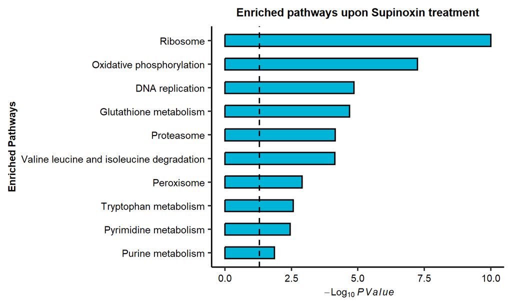

```r
SUP_GSEA = read.table(file = "SUP_GSEA_Results.txt", header = T,
    sep = "\t", quote = "")

my_pathways = c("KEGG_RIBOSOME", "KEGG_OXIDATIVE_PHOSPHORYLATION",
    "KEGG_VALINE_LEUCINE_AND_ISOLEUCINE_DEGRADATION", "KEGG_PROTEASOME",
    "KEGG_DNA_REPLICATION", "KEGG_PYRIMIDINE_METABOLISM", "KEGG_GLUTATHIONE_METABOLISM",
    "KEGG_TRYPTOPHAN_METABOLISM", "KEGG_PEROXISOME", "KEGG_PURINE_METABOLISM")

SUP_GSEA_select = SUP_GSEA %>%
    dplyr::filter(ID %in% my_pathways) %>%
    dplyr::select(all_of(c("ID", "pvalue"))) %>%
    dplyr::mutate(log.Pvalue = log10(pvalue) * -1)

SUP_GSEA_select$ID = str_replace_all(SUP_GSEA_select$ID, "KEGG_",
    "")
SUP_GSEA_select$ID = str_replace_all(SUP_GSEA_select$ID, "_",
    " ")
SUP_GSEA_select$ID = str_to_sentence(SUP_GSEA_select$ID)

SUP_GSEA_select$ID = str_replace_all(SUP_GSEA_select$ID, "Dna ",
    "DNA ")


ggplot(data = SUP_GSEA_select, aes(x = reorder(ID, log.Pvalue),
    y = log.Pvalue)) + ylab(bquote(~-Log[10] ~ italic(PValue))) +
    xlab("Enriched Pathways") + geom_bar(colour = "black", fill = "#00b4d8",
    stat = "identity", width = 0.5) + coord_flip() + theme(axis.text = element_text(size = 7,
    colour = "black")) + theme(axis.title = element_text(size = 7,
    face = "bold")) + theme(panel.background = element_rect(fill = "white")) +
    theme(axis.line = element_line(colour = "black", linewidth = 0.5)) +
    theme(plot.title = element_text(color = "black", size = 8,
        face = "bold", hjust = 0.5)) + ggtitle("Enriched pathways upon Supinoxin treatment") +
    geom_hline(yintercept = 1.3, linetype = "dashed")
```

## Enrichment analysis for DDX5 knockdown data:

5. Enrichment analysis for DDX5 knockdown data was performed using the GSEA function available in clusterProfiler R-package.

```r
# Pathaway analysis (GSEA) for DDX5KD data:

library(clusterProfiler)
library(msigdbr)
library(org.Hs.eg.db)
library(dplyr)

db = "org.Hs.eg.db"

# read “C2” curated gene set from Molecular Signature
# Database (MSigDB)

C2_t2g <- msigdbr(species = "Homo sapiens", category = "C2") %>%
    dplyr::select(gs_name, entrez_gene)

DDK5KD_ranked = read.table(file = "DDK5KD_GSEA.rnk", quote = "",
    sep = "\t", header = T)

DDK5KD_ranked = dplyr::arrange(DDK5KD_ranked, desc(Rank))

x <- bitr(DDK5KD_ranked$Gene_ID, fromType = "ENSEMBL", toType = "ENTREZID",
    OrgDb = db)

x = x %>%
    dplyr::left_join(DDK5KD_ranked, by = c(ENSEMBL = "Gene_ID")) %>%
    dplyr::select(all_of(c("ENTREZID", "Rank"))) %>%
    dplyr::arrange(desc(Rank))


DDK5KD_genelist = x$Rank
names(DDK5KD_genelist) = x$ENTREZID


DDK5KD_GSEA <- GSEA(DDK5KD_genelist, TERM2GENE = C2_t2g, pvalueCutoff = 1)

write.table(DDK5KD_GSEA, file = "DDK5KD_GSEA_Results.txt", sep = "\t",
    quote = F, row.names = F)
```

## compareCluster **(Figure 2B)**:

6. The compareCluster function from clusterProfiler R-package was applied to examine biological (reference: C2 database from MSigDB) profiles of Supinoxin and DDX5 knockdown data and subsequent dot plot displaying simultaneous enrichment of important pathways in each data.

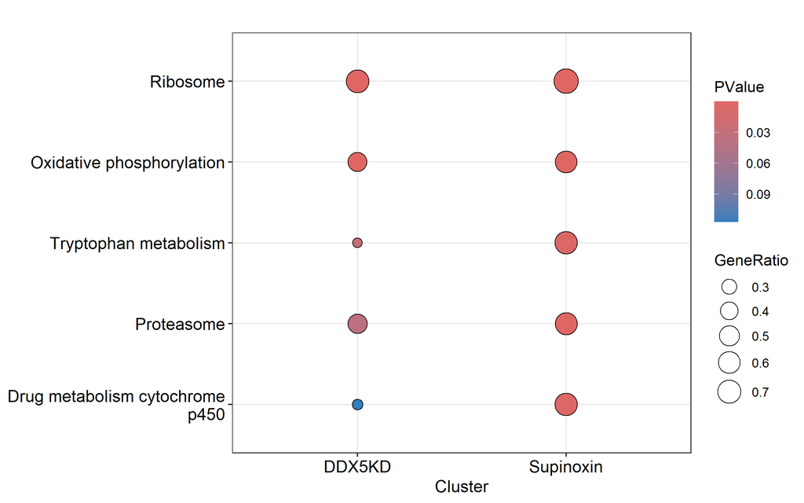

```r
C2_t2g <- msigdbr(species = "Homo sapiens", category = "C2") %>%
    dplyr::select(gs_name, entrez_gene)

SUP_ranked = read.table(file = "SUP_GSEA.rnk", quote = "", sep = "\t",
    header = T)

SUP_ranked = dplyr::arrange(SUP_ranked, desc(Rank))

x <- bitr(SUP_ranked$Gene_ID, fromType = "ENSEMBL", toType = "ENTREZID",
    OrgDb = db)

x = x %>%
    dplyr::left_join(SUP_ranked, by = c(ENSEMBL = "Gene_ID")) %>%
    dplyr::select(all_of(c("ENTREZID", "Rank"))) %>%
    dplyr::arrange(desc(Rank))

SUP_genelist = x$Rank
names(SUP_genelist) = x$ENTREZID

##################################

DDK5KD_ranked = read.table(file = "DDK5KD_GSEA.rnk", quote = "",
    sep = "\t", header = T)

DDK5KD_ranked = dplyr::arrange(DDK5KD_ranked, desc(Rank))

x <- bitr(DDK5KD_ranked$Gene_ID, fromType = "ENSEMBL", toType = "ENTREZID",
    OrgDb = db)

x = x %>%
    dplyr::left_join(DDK5KD_ranked, by = c(ENSEMBL = "Gene_ID")) %>%
    dplyr::select(all_of(c("ENTREZID", "Rank"))) %>%
    dplyr::arrange(desc(Rank))

DDK5KD_genelist = x$Rank
names(DDK5KD_genelist) = x$ENTREZID

##################################

my_list = list(DDX5KD = DDK5KD_genelist, Supinoxin = SUP_genelist)

CCS = compareCluster(my_list, fun = "GSEA", TERM2GENE = C2_t2g,
    pvalueCutoff = 1)

colnames(CCS@compareClusterResult)[7] = "PValue"
CCS@compareClusterResult$ID = str_replace_all(CCS@compareClusterResult$ID,
    "KEGG_", "")
CCS@compareClusterResult$Description = str_replace_all(CCS@compareClusterResult$Description,
    "KEGG_", "")
CCS@compareClusterResult$Description = str_to_sentence((CCS@compareClusterResult$Description))

my_pathways = c("RIBOSOME", "OXIDATIVE_PHOSPHORYLATION", "PROTEASOME",
    "DRUG_METABOLISM_CYTOCHROME_P450", "TRYPTOPHAN_METABOLISM")

my_pathways = str_to_sentence(my_pathways)


x = CCS@compareClusterResult
x$row.ID = rownames(x)

select.pathways = x %>%
    dplyr::filter(Description %in% my_pathways) %>%
    dplyr::pull("Description")

enrichplot::dotplot(CCS, showCategory = select.pathways, color = "PValue")
```

## Supinoxin gseaplot **(Figure 2C)**:

7. The gseaplot was created to visualize the distribution of the gene set and the enrichment score for KEGG_OXIDATIVE_PHOSPHORYLATION pathway in Supinoxin data.

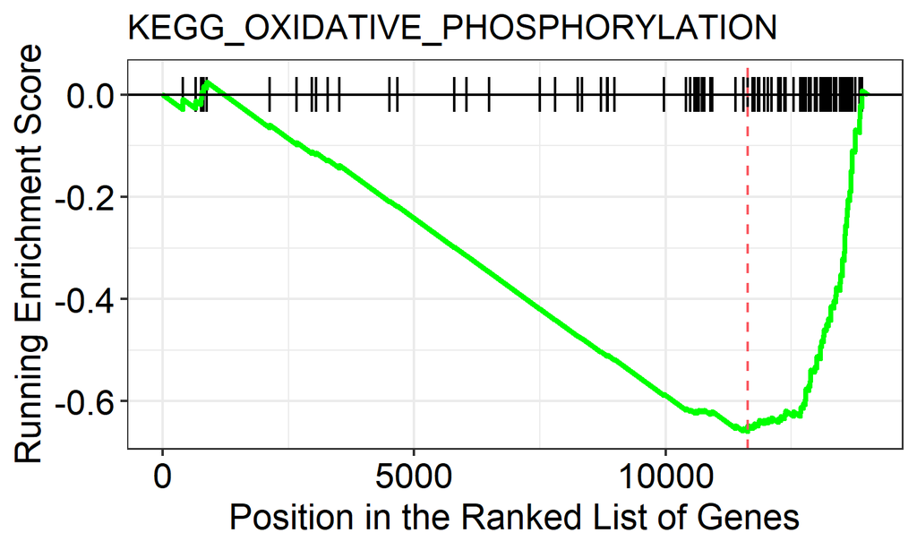

```r
SUP_GSEA = readRDS(file = "SUP_GSEA.rds")

my.index = which(SUP_GSEA@result$Description == "KEGG_OXIDATIVE_PHOSPHORYLATION")

gseaplot(SUP_GSEA, geneSetID = my.index, by = "runningScore",
    title = SUP_GSEA$Description[my.index])
```

## Supinoxin cnetplot **(Figure 2D)**:

8. Gene-concept network plotfor pathway “KEGG OXIDATIVE PHOSPHORYLATION” in Supinoxin data was created using the cnetplot function from clusterProfiler R-package.

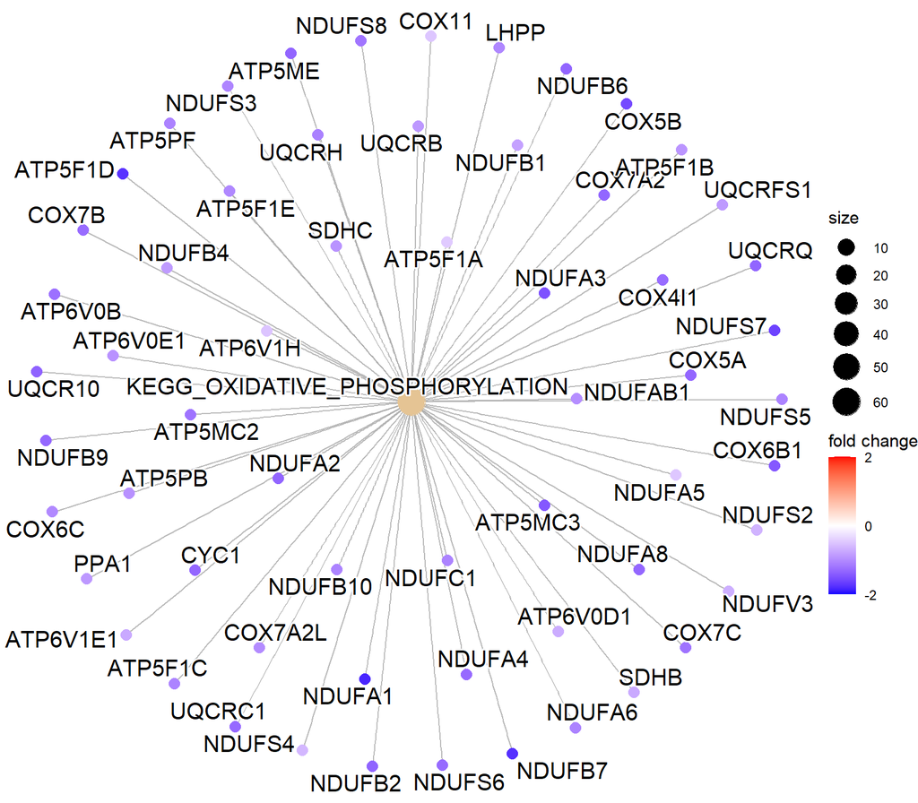

```r
SUP_ranked = read.table(file = "SUP_GSEA.rnk", quote = "", sep = "\t",
    header = T)

SUP_ranked = dplyr::arrange(SUP_ranked, desc(Rank))

x <- bitr(SUP_ranked$Gene_ID, fromType = "ENSEMBL", toType = "ENTREZID",
    OrgDb = db)

SUP.DE = openxlsx::read.xlsx(xlsxFile = "Supinoxin.DE.xlsx",
    sheet = "EdgeR_All")

x = x %>%
    dplyr::left_join(SUP.DE, by = c(ENSEMBL = "Gene_ID")) %>%
    dplyr::select(all_of(c("ENTREZID", "log2FoldChange")))

logFC_genelist = x$log2FoldChange
names(logFC_genelist) = x$ENTREZID

SUP_GSEA = setReadable(SUP_GSEA, "org.Hs.eg.db", "ENTREZID")

p = cnetplot(SUP_GSEA, showCategory = SUP_GSEA@result$Description[my.index],
    foldChange = logFC_genelist, categorySize = "pvalue")

min.value = -2
max.value = 2

p + scale_colour_gradient2(name = "fold change", low = "blue",
    mid = "white", high = "red", limits = c(min.value, max.value),
    breaks = c(min.value, 0, max.value))
```

# Step 11: Confidence Assessment for KEGG Oxidative Phosphorylation (OXPHOS) Network:

## Load STRING Database:

To assess the robustness of gene-concept network within the KEGG Oxidative Phosphorylation (OXPHOS) pathway, we determined if transcriptional enrichment (*adjusted pvalue* = 3.90E-06, normalized enrichment score = -2.11) correspond to subsequent protein-level organization.

```r
# Load Required Libraries
# STRINGdb      : Access STRING protein-protein interactions
# clusterProfiler: GSEA results handling
# igraph        : Network construction and topology metrics
# org.Hs.eg.db  : Gene ID conversion (ENTREZ ↔ SYMBOL)


library(STRINGdb)
library(clusterProfiler)
library(igraph)
library(org.Hs.eg.db)

db = "org.Hs.eg.db"

# Initialize STRING Database
# version 11.5
# species 9606 (human)
# score_threshold = 700 (high-confidence interactions)

string_db <- STRINGdb$new(
  version = "11.5",
  species = 9606,
  score_threshold = 700
)

# Load Precomputed Results
# gsea_result : GSEA enrichment results
# deg         : Differential expression results (edgeR output)

gsea_result = readRDS("SUP_GSEA.rds")
deg = readRDS("SUP_DE.rds")

# Extract OXPHOS Pathway from GSEA Results

gsea_df <- as.data.frame(gsea_result)

# Filter specifically for KEGG Oxidative Phosphorylation pathway
oxphos_row <- gsea_df %>%
          dplyr::filter(Description == "KEGG_OXIDATIVE_PHOSPHORYLATION")

# Compute Pathway-Level Confidence
# term_confidence integrates:
#   - NES magnitude (biological direction/strength)
#   - Adjusted p-value (statistical significance)

term_confidence <- abs(oxphos_row$NES) * -log10(oxphos_row$p.adjust)

# Extract Core Enrichment Genes from GSEA
# core_enrichment contains ENTREZ IDs separated by "/"

core_entrez <- unlist(strsplit(oxphos_row$core_enrichment, "/"))

# Convert ENTREZ IDs to gene symbols for STRING compatibility
core_genes <- bitr(core_entrez,
                       fromType = "ENTREZID",
                       toType   = "SYMBOL",
                       OrgDb    = org.Hs.eg.db)

# Subset Differential Expression Results
# Keep only genes participating in OXPHOS core enrichment

deg_subset <- deg[deg$Gene.name %in% core_genes$SYMBOL, ]

# Compute Gene-Level Confidence
# Combines:
#   - Effect size (|logFC|)
#   - Statistical confidence (-log10 FDR)
# Higher value = strong and statistically reliable gene regulation

deg_subset$gene_confidence <- abs(deg_subset$logFC) * -log10(deg_subset$FDR)

mean_gene_conf <- mean(deg_subset$gene_confidence, na.rm = TRUE)
```

## Mapping OXPHOS genes to STRING Database:

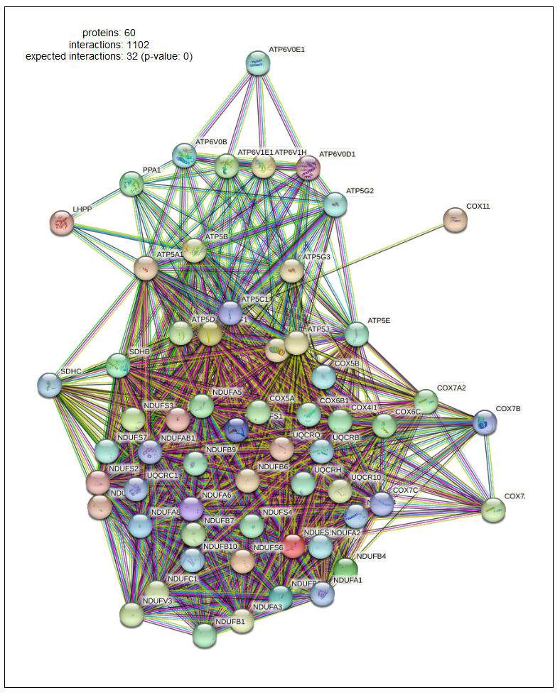

```r
# Map Gene Symbols to STRING IDs
# Required for retrieving PPI interactions

mapped_genes <- string_db$map(
  deg_subset,
  "Gene.name",
  removeUnmappedRows = TRUE
)

string_ids <- mapped_genes$STRING_id

# Retrieve All Interactions Between OXPHOS STRING IDs

interactions <- string_db$get_interactions(string_ids)
dim(interactions)  # shows number of interaction pairs retrieved

# Quick visualization of full STRING network
string_db$plot_network(mapped_genes$STRING_id)
```

## Assessment of OXPHOS protein-protein interactions:

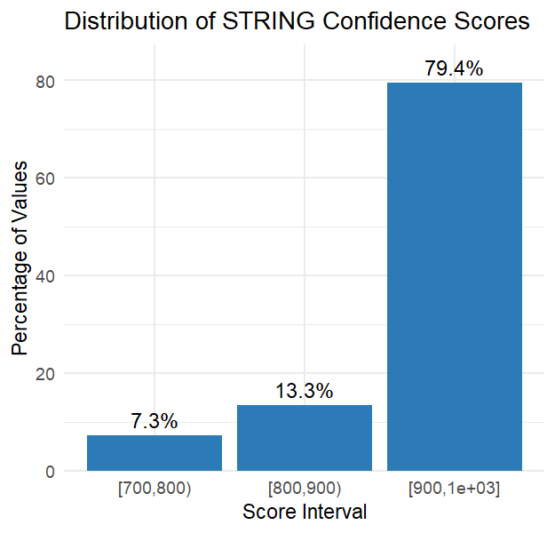

```r
library(dplyr)
library(ggplot2)

# Examine Distribution of STRING Confidence Scores
# combined_score ranges from 700–1000 (high-confidence threshold applied)
# This step visualizes robustness of interaction evidence

df_binned <- interactions %>%
  mutate(
    bin = cut(
      combined_score,
      breaks = seq(700, 1000, by = 100),
      include.lowest = TRUE,
      right = FALSE
    )
  ) %>%
  count(bin) %>%
  mutate(percent = n / sum(n) * 100)



ggplot(df_binned, aes(x = bin, y = percent)) +
  geom_col(fill = "#2C7BB6") +
  geom_text(aes(label = sprintf("%.1f%%", percent)),
            vjust = -0.5, size = 5) +
  scale_y_continuous(expand = expansion(mult = c(0, 0.1))) +
  labs(
    x = "Score Interval",
    y = "Percentage of Values",
    title = "Distribution of STRING Confidence Scores"
  ) +
  theme_minimal(base_size = 14)
```

Distribution of STRING confidence scores within OXPHOS interaction network was examined. As denoted in the plot above, >79% interactions within OXPHOS network have very-high-confidence (>900) score and remaining >20% interactions have high-confidence scores (>700) score indicating highly structured and biologically cohesive protein interaction network.

## Enrichment analysis of OXPHOS protein-protein interactions:

Next, protein–protein interaction (PPI) enrichment analysis was performed. The OXPHOS network contains 1102 observed edges (ppi_edges) compared to 32 expected edges (ppi_lambda). PPI enrichment analysis *pvalue* (ppi_pvalue) was reported as 0, indicating highly significant overrepresentation of interactions than random chance. To account for machine precision limits (i.e. *pvalue* reported as 0), the smallest positive double value was used to compute a conservative −log10-transformed enrichment metric, yielding a robust quantitative estimate of PPI confidence. Further, a **composite network confidence score** was computed as function of OXPHOS pathway enrichment significance, average of gene-level differential expression strength and PPI enrichment magnitude. High composite network confidence score affirms the significance of OXPHOS pathway network.

```r
# Perform STRING PPI Enrichment Test
# Tests whether observed connectivity >> expected random connectivity

ppi_enrichment <- string_db$get_ppi_enrichment(string_ids)

ppi_pvalue <- ppi_enrichment$enrichment   # enrichment p-value
ppi_edges  <- ppi_enrichment$edges        # observed edges
ppi_lambda <- ppi_enrichment$lambda       # expected edges

# Handle Extremely Small p-value
# If enrichment p = 0 (underflow), substitute smallest positive double

min_p <- .Machine$double.xmin
ppi_confidence <- -log10(min_p)

# Composite Network Confidence Score
# Integrates:
#   - Pathway-level significance
#   - Gene-level differential expression strength
#   - PPI enrichment strength

network_confidence_score <- term_confidence * mean_gene_conf * ppi_confidence
```

## Topological analysis of OXPHOS protein-protein interactions:

Next, topological analysis was performed to quantitatively characterize the structural organization of a protein–protein interaction (PPI) network. Topological analysis revealed the organization of protein interactions and associated key genes (termed as hub genes) that are strong contributors to network integrity. First an igraph object (g) was built from OXXPHOS interactions followed by simplification of graph object by removing duplicate edges and self-loops (i.e. removing technically redundant interactions). Resulting simplified graph was comprised of 60 nodes and 1,102 non-redundant edges and corresponding network density of 0.62 (i.e. 62% of all theoretically possible pairwise interactions are retained within simplified graph object). Subsequent calculation of degree centrality identified nodes with high number of connections. Nodes with highest degree centrality were used to determine top 10 hub genes that form core components within the OXPHOS network. Visualization of core OXPHOS network (i.e. protein-protein interactions associated with top 10 hub genes) was performed.

[figure not shown]

```r
# Build igraph Object for Topological Analysis

library(igraph)

g <- graph_from_data_frame(
       interactions[, c("from", "to")],
       directed = FALSE)

# Remove duplicate edges or self-loops for accurate topology
g <- simplify(g)

# Basic Network Metrics
num_nodes   <- vcount(g)
num_edges   <- ecount(g)
density_val <- edge_density(g)

# Degree centrality (number of connections per gene)
deg_cent <- igraph::degree(g)

# Identify Top Hub Genes
# Select top 10 genes with highest connectivity

hub_genes <- names(sort(deg_cent, decreasing = TRUE))[1:10]

# Convert STRING IDs back to gene symbols for interpretation
hub_ids <- mapped_genes$Gene.name[mapped_genes$STRING_id %in% hub_genes]

hub_interactions <- mapped_genes %>%
                       dplyr::filter(Gene.name %in% hub_ids)

# Plot network focusing only on hub genes
string_db$plot_network(hub_interactions)
```

## Conclusion:

First, the mapping of OXPHOS network to STRING interactions indicate extensive inter-protein connectivity and >79% interactions with very high confidence score (>900) denote biological and functional relevance of protein-protein interactions. Enrichment testing of protein-protein interactions revealed highly significant *pvalue* confirming that PPI network connectivity exceeds random expectation. Finally, topological analysis moved beyond simple interaction counts and quantitatively characterized the structural organization of a protein–protein interaction network and revealed the hub genes that contribute most strongly to network integrity. Collectively, these analyses indicate that OXPHOS pathway in not only transcriptionally enriched but also forms a structured, biologically cohesive protein-protein interaction network with hierarchical organization and central hub genes. This reinforces our findings that OXPHOS perturbations are coordinated pathway level remodeling activity rather than simple gene-level variations.